# Data Manipulation and Visualization

Jungmin Chang

Data visualization really helps us to understand data. To visualize our data, the `ggplot2` package can be used. This package sequentially builds up graphs using `geoms` following a grammar of graphics (gg) principles. If you are unfamiliar with this package then Chapter 3 of [R for Data Science](https://r4ds.had.co.nz/data-visualisation.html) provides a concise introduction.

##### 1. Creating a scatter plot

First, we read in *gapminder data* that we will use for data visualization projects from the `Gapminder package`. Then we create a scatter plot of life expectancy versus GDP using `ggplot()` and the `gapminder` dataset, and show the data as a series of points. A scatter plot uses dots to represent values for two different numeric variables.

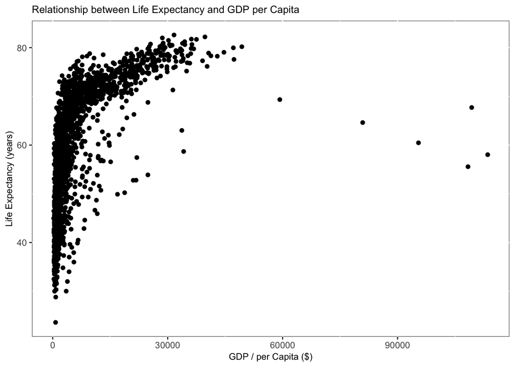

```r
# read in data
gapminder.df <- data.frame(gapminder)
ggplot(gapminder.df, aes (gdpPercap, lifeExp)) +
  geom_point() +
  labs(title = "Relationship between Life Expectancy and GDP per Capita", y = "Life Expectancy (years)", x = "GDP / per Capita ($)") +
  theme(plot.title = element_text(size = 10), axis.title = element_text(size = 9), panel.background = element_rect(fill = 'white', color = "grey40", linetype = "solid"))
```

##### 2. Plotting a smooth line

##### 2.1 Geom_smooth()

To better understand the distribution of data, we can plot a smooth line which is an estimate of the conditional mean function conditional on x variable including its standard error range.

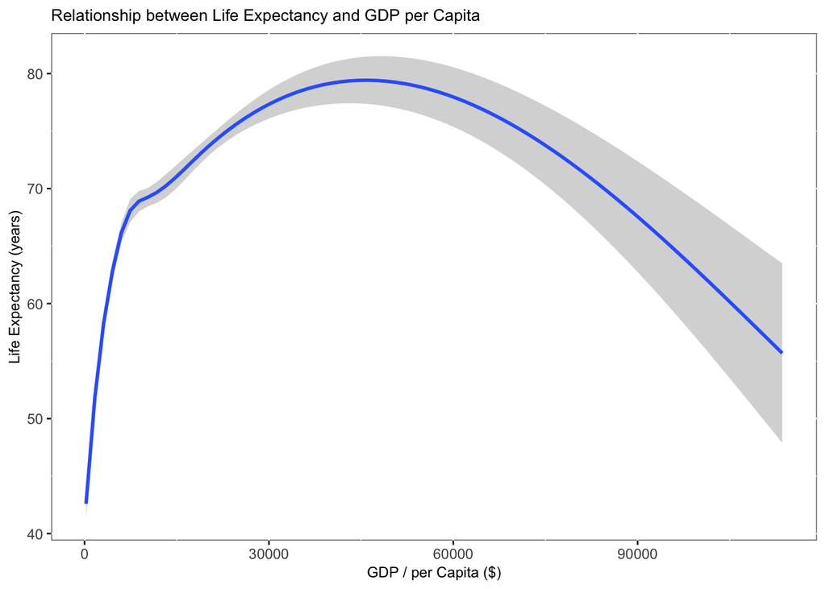

```r
ggplot(gapminder.df, aes (gdpPercap, lifeExp)) +
  geom_smooth() +
  labs(title = "Relationship between Life Expectancy and GDP per Capita", y = "Life Expectancy (years)", x = "GDP / per Capita ($)") +
  theme(plot.title = element_text(size = 10), axis.title = element_text(size = 9), panel.background = element_rect(fill = 'white', color = "grey40", linetype = "solid"))
```

##### 2.2 Geom_smooth(method = “lm”)

Using the same variables in 2.1, we can include the data points on the plot and change the smooth line to be a linear regression model

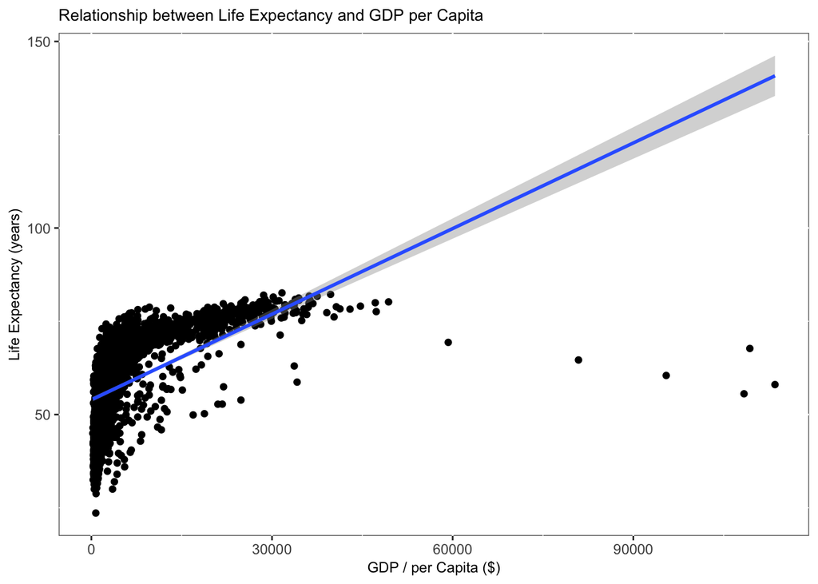

```r
ggplot(gapminder.df, aes (gdpPercap, lifeExp)) +
  geom_point() +
  geom_smooth(method = lm) +
  labs(title = "Relationship between Life Expectancy and GDP per Capita", y = "Life Expectancy (years)", x = "GDP / per Capita ($)") +
  theme(plot.title = element_text(size = 10), axis.title = element_text(size = 9), panel.background = element_rect(fill = 'white', color = "grey40", linetype = "solid"))
```

##### 3. Taking a log of skewed data

It seems like GDP is not normally distributed and rather clustered on the left side of the graph. Once we log of actual GDP values the distribution of GDP becomes closeR to normal distribution.

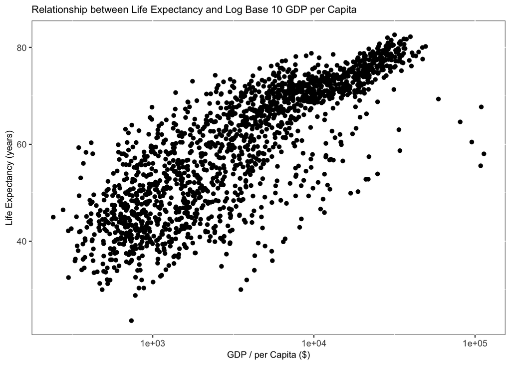

```r
ggplot(gapminder.df, aes (gdpPercap, lifeExp)) +
  scale_x_continuous(trans = 'log10') +
  geom_point() +
  labs(title = "Relationship between Life Expectancy and Log Base 10 GDP per Capita", y = "Life Expectancy (years)", x = "GDP / per Capita ($)") +
  theme(plot.title = element_text(size = 10), axis.title = element_text(size = 9), panel.background = element_rect(fill = 'white', color = "grey40", linetype = "solid"))
```

##### 4. Distiguishing the values according to their corresponding continents with color

##### 4.1 Colors

Classifying each continent with different colors helps us to understand the relationship between life expectancy and GDP per capita across the continents.

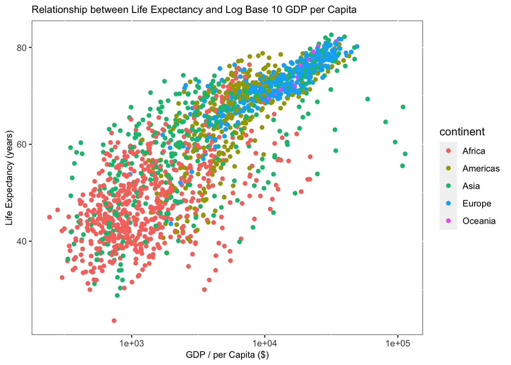

```r
ggplot(gapminder.df, aes (gdpPercap, lifeExp, color = continent)) +
  scale_x_continuous(trans = 'log10') +
  geom_point() +
  labs(title = "Relationship between Life Expectancy and Log Base 10 GDP per Capita", y = "Life Expectancy (years)", x = "GDP / per Capita ($)") +
  theme(plot.title = element_text(size = 10), axis.title = element_text(size = 9), panel.background = element_rect(fill = 'white', color = "grey40", linetype = "solid"))
```

###### 4.2 Add a linear mode of line

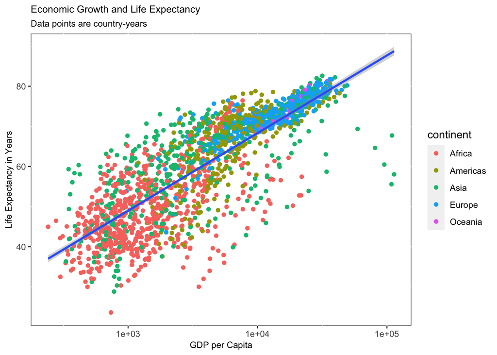

```r
ggplot(gapminder.df, aes (gdpPercap, lifeExp)) +
  scale_x_continuous(trans = 'log10') +
  geom_point(aes(color = continent)) +
  geom_smooth(method = lm) +
   labs(title = "Economic Growth and Life Expectancy", subtitle = "Data points are country-years", y = "Life Expectancy in Years", x = "GDP per Capita") +
  theme(plot.title = element_text(size = 10), plot.subtitle = element_text(size = 9), axis.title = element_text(size = 9), panel.background = element_rect(fill = 'white', color = "grey40", linetype = "solid"))
```

##### 5. Facet_grid

Instead of plotting all continents in one graph, we can separate them by plotting several different graphs using `facet_grid`.

[figure not shown]

```r
ggplot(gapminder.df, aes (gdpPercap, lifeExp)) +
  geom_line() +
  geom_smooth(method = "lm") +
  facet_grid(cols = vars (continent)) +
  labs(title = "GDP per capita on Five Continents", y = "GDP per capita", x = "Year") +
  theme(plot.title = element_text(size = 10), axis.title = element_text(size = 9))
```

##### 6. Manipulating Data

Data manipulation is an important step to cleaning and organizing the data. Data manipulation can make data exploration easier. The `dplyr` package contains handy functions to manipulate data; `filter`, `select`, `mutate` or `arrange`. On the other hand, the `tidyr` package is useful to reshape data;e.g. to change its format from wide to long (and vice versa).

##### 6.1 Select

We can choose specific columns from our data set by using `select`

```r
subdata <- gapminder.df %>%
  select(country, year, gdpPercap)
head(subdata)
```

```
##       country year gdpPercap
## 1 Afghanistan 1952  779.4453
## 2 Afghanistan 1957  820.8530
## 3 Afghanistan 1962  853.1007
## 4 Afghanistan 1967  836.1971
## 5 Afghanistan 1972  739.9811
## 6 Afghanistan 1977  786.1134
```

##### 6.2 Filter

While `select` enables us to choose specific columns from our data set, `filter` helps us to choose specific rows with equivalent values we want to print. For instance, we can create a subset of `subdata` where the `year` associated with the observations is either 1952, 1957, 2002 or 2007

```r
subdata_b <- subdata %>%
  filter(year == "1952"| year =="1957" | year == "2002"| year == "2007")
```

##### 7. Creating a barplot

While a scatter plot has the benefit of displaying relationship between numeric variables, a barplot can be used to compare discrete variables.

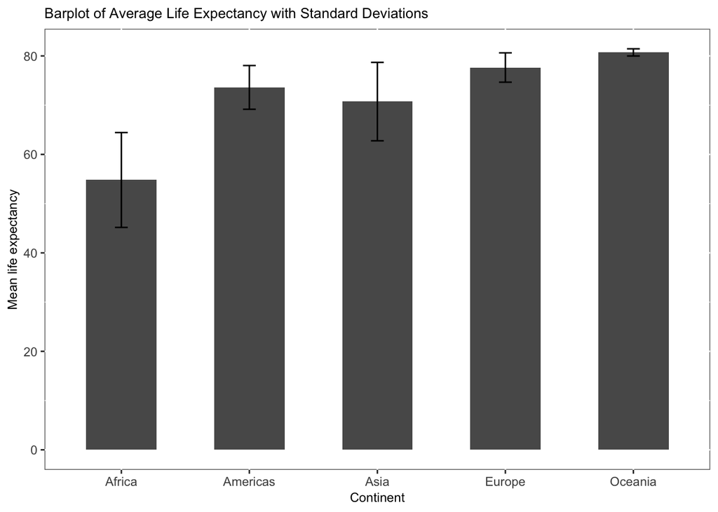

```r
# a) filter data with year 2007
gap2007 <- gapminder.df %>%
  filter(year == "2007")

# c) create a barplot
gap2007 %>%
  group_by(continent) %>%
  summarize(mean= mean(lifeExp), sd = sd(lifeExp)) %>%
  ungroup() %>%
  mutate(continent = factor(continent)) %>%
  ggplot(aes(x=continent, y=mean)) +
  geom_col(width = .55) +
  scale_y_continuous(name = "Mean life expectancy") +
  scale_x_discrete("Continent") +
  labs(title = "Barplot of Average Life Expectancy with Standard Deviations", y = "Mean life expectancy", x = "Continent") +
  theme(plot.title = element_text(size = 10), axis.title = element_text(size = 9),panel.background = element_rect(fill = 'white', color = "grey40", linetype = "solid")) +
  geom_errorbar(aes(ymin=mean-sd, ymax=mean+sd), width=.1,                    # Width of the error bars
                  position=position_dodge(.7))
```

Oceania has the highest life expectancy in average out of the five continents followed by Europe. Africa has the shortest mean life expectancy with higher standard deviations.